## Acknowledgements

I would like to begin by thanking my professors, Professor Christopher Timmins, Professor Colin Rundel and Professor Grace Kim. Thank you to Professor Timmins for your support and guidance at all hours of the day, and for constantly challenging me to think critically about the questions I was asking and the methodology I was using. It was a pleasure working with you this year, and I learned so much from you. Thank you to Professor Rundel for your wisdom and patience. I did not realize that pursuing research was not only an academic pursuit but also a huge emotional undertaking, and your insight and calming presence was so critical in this process. Thank you for listening to every idea I had with an open-mind, and walking with me through the detailed processes necessary to get answers to each of these curiosities. Thank you also to Professor Grace Kim for your feedback and your constant support of my winding research path, as well as of my career throughout Duke. Thank you to John Killeen at DataWorks. Without your trust in me to pursue this research question with the care it deserves, this research would not have been possible. Thank you for all of the brainstorming sessions and hours spent investigating imperfect data problems. I learned so much through your mentorship. Thank you to the Durham Sherriff’s Department and Durham Tax Administration for letting me work with this data in my thesis. Finally, thank you to all of the friends who have kept me sane as I panicked about this research project: Anna-Karin Hess, David Pfeiffer, and Juan Philippe, I could not have done this without your support!

## Dedication

I would like to dedicate my thesis to my dad, who enjoys doing research as a fun hobby and inspired me to think that I might be the same. Guess this is one of the few ways that we are different, dad!

# Abstract

This thesis investigates the changes in the ownership of multi-family rental complexes in Durham between 2000 and 2018 and their subsequent impact on housing stability. Specifically, I model and compare the likelihood that an eviction filing is issued by corporate and individual landlords in the periods before and after a transaction. Since the early 2000s, institutional investor share in all property sizes has increased dramatically in the United States. In 2013, the Blackstone Group released the first-ever rated bond backed by single-family securitized rental payments, and since then, numerous firms have followed with similar security offerings, which as of 2018 include bonds backed by multi-family rental income. The surge of institutional investment in multi-family rental properties and its impacts on communities have remained largely ignored in academic literature. Durham County currently holds one of the highest eviction rates in North Carolina and ranks in the top 40 of highest evicting large cities in the United States. In my thesis, I uncover how ownership of rental properties in Durham has changed since the early 2000s and investigate whether the behaviors of “corporate landlords” differ significantly from those of individual investors (or “mom and pop” landlords”). I find that the proportion of properties under corporate ownership has increased across all property sizes since 2000, and the proportion of corporate owners that are based out-of-state has also increased. I also find evidence to suggest that different sizes of multi-family properties should be examined distinctly, as I uncover different trends across property sizes in both ownership and eviction rates. Using a fixed effects model, I find that overall, individuals appear to have a higher likelihood of filing an eviction against a tenant compared to institutional landlords in the months before and after a transaction. Finally, I find that large investors amongst both corporates and individuals, defined as investors that own more than 15 properties in Durham, are significantly more likely to evict than smaller investors are.

*Keywords*: Housing stability, real-estate, multi-family rental market, institutional investor, corporate landlord

# Introduction

Over the past decade, Durham residents have been struggling with the forces of gentrification redesigning their neighborhoods and often leaving them out of the blueprint. Gentrification, defined in one economics paper as the “influx of wealthier residents accompanied by rising property prices and the displacement of existing, lower-income residents” is a phenomenon evident in multiple cities across the nation (definition from Raymond et. al, 2016). A Gentrification Report released by Governing examining the nation’s 50 largest cities in 2015 found that nearly 20 percent of neighborhoods with lower incomes and home values experienced gentrification since 2000 (Maciag, 2015). My thesis aims to explore one factor related to the displacement of tenants in Durham: the rate at which formal evictions are filed by corporate and individual landlords, as specified by The Rental Housing Finance Survey[^1].

Formal evictions, or evictions processed through the court system, are not the only method by which a tenant may be displaced. The displacement process for a tenant can take many different forms but many of these moves are difficult to document and measure. A forced move is defined by the United Nations as “the permanent or temporary removal against their will of individuals… from the homes… which they occupy, without the provision of, and access to, appropriate forms of legal or other protection” (United Nations). Forced moves include cases such as landlords changing tenant’s locks or increasing rents, which force residents to relocate because they can no longer afford their apartments (Desmond, 2016, Who Gets Evicted?). These forced moves do not leave clear paper trails. Yet, they are still major reasons low-income tenants end up displaced from their communities. According to Desmond’s findings from the MARS Project, informal evictions were twice as common (48 percent) as formal evictions (24 percent) in forced moves (Flowers, 2018). By focusing on formal ejectment filings, my thesis will necessarily underestimate the magnitude of the displacements in Durham. The aim of this research is not to explore and measure the various causes of displacement, but rather to investigate the differences in the use of eviction filings to displace tenants amongst different types of owners in Durham’s multi-family rental market.

The eviction crisis is an important epidemic, especially when we recognize the changing landscape of homeownership and renter-ship in the United States. Following the 2008 financial crisis, homeownership lost its role as a key element of the American Dream, replaced by a new demographic of renters. Homeownership rates declined from 68.4 percent in the first quarter of 2007 to 62.9 percent in the first quarter of 2016, which is the lowest they have been since homeownership rates started being reported back in 1965 (U.S. Census Bureau, “Homeownership Rate”). By the end of 2016, renters out-numbered homeowners in 22 more of the 100 largest cities in the United States, bringing the total number of renter-majority cities to 42 (Szekely, 2018). Since 2016, rates have steadily increased back to around 64.8 percent in the last quarter of 2018, but this is still much lower than pre-financial crisis levels (U.S. Census Bureau, “Homeownership Rate”).

Not only has there been a dramatic change in the composition of communities across the United States, but there also appears to have been a change in the composition of who owns these properties. In the past decade, rental markets across dozens of cities, previously dominated by mom-and-pop landlords, have slowly been replaced by non-individual investors[^2] (Kolomatsky, 2017). Between 2001 and 2015, non-individual investors gained the majority share of rental units (52.2 percent) as a result of increased ownership of multi-unit properties (Kolomatsky, 2017). In fact, institutional investors have gained shares across all sizes of rental properties since 2001 (Kolomatsky, 2017). There are several real estate investment trusts (REITs) and private equity firms in the United States that currently operate portfolios consisting of tens of thousands of single-family properties, dispersed in different cities across the nation (Mills et. al, 2016). Recently, multi-family property rentals have also begun to pique the interest of large financial institutions and property managers such as Freddie Mac and Fannie Mae, though these properties remain largely ignored in research related to institutional investment in real-estate markets compared to single family residences.

Furthermore, recent studies have begun to investigate the strategies employed by these “corporate” landlords and evaluate their impact on housing instability (Raymond et. al, 2016; Fields & Uffer, 2016; Immergluck, 2013; Herbert et. al, 2013; Mallach, 2013; Ford et. al, 2013). However, there is no research currently focused on understanding the relationship between the owners of multi-family units and their eviction filing rates. This seems like a natural relationship to investigate, particularly in cities with high rates of evictions. One community that stands at the intersection of high investment and high eviction rates is Durham County, North Carolina.

This paper proceeds as follows. I begin with an overview of the background of Durham and explain why it serves as a good case study for exploring my research questions. Next, I present the relevant literature on rental ownership and housing stability in the United States and give historical context to provide motivation for why the topic is so pressing. Following the Literary Review, I provide an in-depth discussion of my data preparation and manipulation process, including an overview of my rigorous hand-coding system to identify different types of owners. As part of my data section, I look at the changes in ownership of Durham’s multi-family rental properties between 2000 and 2018. Specifically, I look at the differences in ownership trends amongst corporates and individuals, as well as ownership trends between out-of-state and in-state corporates.

Next, I provide a theoretical framework from which to think about this problem and present the empirical specifications of my fixed effects model. I apply this framework on various landlord characteristics, including landlord type (whether the landlord is a corporate or individual), landlord location (whether the landlord’s headquarters are based), and landlord size (whether the landlord owns more than 15 multi-family properties in Durham). I present my results along with numerous sensitivity analyses in my Results section. Finally, I discuss the implications of my findings, including potential ideas for further research, and conclude.

This paper makes several contributions to the empirical literature on rental property ownership and eviction rates. First, it presents one of the only attempts to directly link rental property ownership to eviction rates.[^3] It is the first paper that specifically focuses on uncovering the changes in the multi-family rental market at such a detailed level. Specifically, I document the changes in ownership between corporates and individuals as well as between out-of-state and in-state corporate investors of Durham’s multi-family rental market between 2000 and 2018. Second, using a fixed effects model, I explore the differences in the likelihood of an eviction filing based on different landlord characteristics. Finally, I find evidence to suggest that the likelihood of a specific type of landlord evicting a tenant differs across property sizes. Therefore, I suggest that multi-family dwellings should not be lumped together when conducting analysis, but rather, different property size groups should be uniquely analyzed.

# Literary Review

## Backround

Durham County currently has a population of over 300,000 residents. Since 2000, the population has increased a whopping 50%, two-thirds of which is attributable to the heavy influx of new residents. 85% of the Durham population currently lives in the city of Durham. According to Mayor Steve Schewel, in 2018, the city of Durham saw an influx of 20 new residents every single day. That adds up to approximately 7,000 people each year, which places Durham as the fourth highest city in people moving in, per capita, in North Carolina (Krueger, 2018).

Furthermore, migrants pouring into Durham are on average richer than residents currently living in Durham, especially in the downtown area. The average new resident in Durham makes approximately $13,000 more a year than current residents do (Vaughan, 2018). As more residents pour into the county, and job growth continues to grow, residents have seen a rise in rents, specifically in the Triangle area (Eanes, 2019). Further, apartment occupancy rates are at the highest they have been in the past 20 years, which means tenants have less room to negotiate with their landlords on rental contracts (Eanes, 2019).

To meet this new demand for housing, 4,316 new housing units, including single-family homes, duplexes and apartments were built in 2017, up from 4,015 units in 2016 (Krueger, 2018). As the skyline of Durham continues to change, it is important to understand the types of entities that are investing in the community. My thesis aims to tackle one part of that investigation: specifically, I uncover how the ownership of the county’s multi-family dwellings have changed. As residents and investments continue flooding in, Durham County currently faces one of the highest eviction rates in the country and the state. In the 2015-2016 fiscal year, one eviction case was filed for every twenty-eight Durham County residents, putting Durham County at the highest eviction rate among the ten largest counties in North Carolina (Willets, 2017).

The increases in investment and construction in Durham County in the past decade coupled with the current eviction crisis make it an interesting case study for my thesis. As it stands, there is little research that looks at the systematic changes in ownership of rental properties across our nation’s cities, and its subsequent impact on housing stability. Given the unique position of Durham County as a hot spot for evictions as well as a hub for investment, I contend that it is one of the best places to begin to explore this relationship. The distinct contribution of this paper is to investigate the changes in ownership of Durham’s multi-family rental market between 2000 and 2018 and what it reveals about Durham’s eviction crisis.

## Literary Review

### History of Investment in the Rental Market

The subprime meltdown and financial crisis of 2008 led to high rates of foreclosures in the United States, which led to serious imbalances in the housing market. At the core of this imbalance was the excess supply of owner-occupied housing and a very low demand for it, coupled with a heightened demand for renting. There were a number of reasons that these imbalances came to exist. Firstly, there were restraints on mortgage credit following the crisis. Many lending institutions tightened underwriting conditions dramatically, so consumers were unable to secure loans to buy homes. Further, there was an extra reluctance to extend credit to borrowers who actually could meet the underwriting standards currently set by the GSEs, or government-sponsored enterprises, leading to even more reduced levels of lending. Specifically, lending to first time homebuyers dropped precipitously, a demographic which represented an important source of incremental housing demand. Therefore, families that were either unable to or reluctant to purchase homes started entering the rental market in large swaths. Rents started to rise and vacancy rates for multifamily properties were on the decline in most metropolitan areas by 2012 (America’s Rental Housing, 2013).

In 2012, in order to meet the high demand for renting and stabilize the rental market, the Federal Reserve suggested that private equity firms invest in foreclosed homes and turn them into rental properties (Bernanke, 2012). Perhaps to create incentive, Chairman Ben S. Bernanke also stated that REO (real-estate owned) holders would make more money by renting rather than selling their properties (Bernanke, 2012). The geography of the foreclosures coupled with the low price-to-rent-ratios spurred investment mainly in the “Sun Belt” region across the United States, which stretched across the Southeast to the Southwest, including states like California, Texas, Arizona and Georgia. In various cities, such as Las Vegas and Boston, investors were able to channel a tremendous amount of capital into distressed areas, which likely did stabilize – at least in the short-term – occupancy of foreclosed properties in the absence of effective demand by owner‐occupants (Herbert et. al, 2013a). However, the long-term impacts of these new institutional investors on the community were yet to be seen.

The investments made post-financial crisis were not the first-time institutional investors entered the rental market in large numbers. A combination of low stock market returns, low interest rates in the early 2000s, and a tight rental market created a prime opportunity for investment in multifamily rental housing in New York several years before the housing crisis (Fields, 2015). Between 2005 and 2009, private equity funds bought up approximately 100,000 units, which represented around 10 percent of the supply of rent-stabilized housing in New York (Association for Neighborhood and Housing Development (ANHD), 2009). The investors paid extremely inflated prices for these properties, based on appraisals that underestimated operating expenses and overestimated rental income (ANHD, 2009). Thus, the firms were unable to make returns keeping the rents at current levels and began to engage in what advocates later termed, “predatory equity” practices, which included displacing tenants through eviction filings in order to raise rates, or intentionally cutting back on maintenance costs and letting building conditions deteriorate to unlivable conditions (Fields, 2015). These tactics were used with the goal of securing double-digit returns in the rental market (Fields, 2015).

### Recent Trends in the Rental Markets

The entry of institutional investors into the rental market continues to grow. Historically, the single-family segment of the rental market has been classified as a “real goods” market, comprised of small investors with small inventories. However, the financial liberalization and changes in housing policies have created market conditions that are favorable to larger investors (Fields & Uffer, 2016; Immergluck, 2013; Herbert et. al, 2013b; Mallach, 2013). According to the Rental Housing Finance Survey conducted in 2015, individual investors are still the biggest group in the rental housing market in 2015, accounting for 74.4 percent, or 16.7 million rental properties (US Census Bureau). However, individual investors owned less than half (47.8 percent) of rental units, since property size tends to be smaller among smaller investors (Lee, 2017). While non-individual investor share in all property sizes has increased since 2001, the most significant increase in their ownership share has been in properties with 5-24 units, where non-individual investors now own 62 percent of these properties compared to 35 percent in 2001. Overall, non-individual investors continue to have a majority share in properties with over 25 units but are a minority in properties with 2-4 units (23 percent), which allows for continued market penetration (Kolomatsky, 2017).

Perhaps, the reason financial institutions are so interested in the rental market is because it is increasingly seen by the financial sector as a new investment opportunity with the potential to yield high returns. Eisfeldt and Demers published a paper in the National Bureau of Economic Research in 2015 that studied the total returns that could be achieved in the single-family rental market, analogizing the dividend yields and capital gains that constitute total equity returns to rental yields and house price appreciation, which they deemed as the two components for rental returns. The researchers then studied how much return could be made in different price tiers and regions of the United States’ single-family rental market (Eisfeldt and Demers, 2015).

Historically, institutional management faced barriers to entry into the real-estate space such as high management costs, risks associated with renters’ vulnerability to economic shocks, and the absence of a track record for structured finance opportunities (Berry, 2000). Fields, in a paper published in 2018 discusses how these barriers have been breached by private equity firms in the past decade and traces the history of the financialization of the rental space (Fields, 2018). This recent research demonstrates the financial sector’s growing interest and view of the rental markets as investment opportunities.

The main reason I expect the behaviors of corporate investors to be different than individual and non-corporate investors lies in their fundamental motivations. Private equity firms typically seek returns of 10-20 percent a year over relatively short investment terms; in contrast to this, real goods markets such as housing have generated moderate profits in the single-digit range (Fields, 2016; Evans & Habbard). This highlights a fundamental discrepancy in the motivations between the usual small investor base in the real estate market and the expectations being placed by new financial players on the housing market.

In the last five years, institutional investors with large portfolios of rental homes have begun financing these portfolios through single-family rental (SFRs) securitizations, which are backed by rent checks from the portfolios of thousands of single-family rentals. In November 2013, the Blackstone Group released the first-ever rated bond backed by securitized rental payments, and since then, numerous firms, including American Homes 4 Rent, have followed with similar security offerings (Gottesdiener, 2017). Even then, tenant advocates voiced concern over the potential future for residents whose homes made up parts of these portfolios, and with reason. According to an article in 2014 from the Los Angeles Times, American Homes 4 Rent expressed they were met with “relatively little resistance” as they began “experimenting this Spring with 4 percent to 5 percent rent hikes on lease renewals” (Logan, 2014).

The financing of portfolios of this size also occur through the capital structure of publicly traded real-estate investment trusts (REITs). The presence of REITs and the number of SFRs have continued to increase in recent years, both of which fundamentally treat renters’ homes as publicly traded financial assets, often without the express knowledge of the tenants. By leveraging their investments in this way, these firms are able to buy higher numbers of properties, which makes them an especially important case to investigate.

Much like the predatory equity practices in New York a decade ago, recent studies have already pointed to the possibility of abusive practices in recent years from institutional investors. In Atlanta, a study on corporate landlords and displacement found that larger investors, defined as those with over 15 single-family properties in the city, were eight percent more likely to evict than other landlords in single-family residences (Raymond et. al, 2016). The study also revealed that areas with high levels of evictions corresponded to predominantly black neighborhoods in the southeast corner of the city. In a paper published in 2016, Fields et. al investigated SFR securitization products and found that among the first 15 securitizations ever offered, only one firm, Invitation Homes, included properties rented to tenants with Section 8 vouchers (Fields et. al, 2016). Taking Section 8 tenants as a proxy for low-income accessibility, this would suggest that low-income tenants may have limited accessibility to rentals owned by these landlords. Finally, distant investor landlords make it more difficult for tenants to hold landlords legally and politically accountable at the local level when they have problems with their living conditions or are being evicted for corrupt reasons (Fields et. al, 2016). Part of the reason for this is that institutions often invest through other investment vehicles such as shell companies, which can make it difficult for tenants to not only reach landlords to solve issues, but to determine who the beneficial owner truly is. This suggests that owners based out-of-state may have a higher likelihood to evict than tenants based in-state.

Recent studies have begun to study the unique strategies institutional investors take to obtain returns on their investments: strategies that often have negative consequences for tenants. Mallach places distressed property investors into four broad categories: rehabbers, flippers, milkers and holders (Mallach, 2010). Rehabbers and flippers refer to investors who intend to make their return by reselling the property, with the main difference being that rehabbers are more focused on investing in necessary capital improvements, while flippers typically put minimal investment before selling the property quickly. On the other hand, milkers and holders do intend to hold the properties but while “milkers” extract high rents with little investment, allowing building conditions to deteriorate, and subsequently dump the property on the market or the municipality, “holders” seek profits through home price appreciation, placing more importance on maintenance, and may keep properties vacant until prices rise (Mallach, 2010).

Researchers have applied Mallach’s framework to numerous case studies conducted in Atlanta, Boston, Las Vegas and Cleveland (Immergluck, 2013; Herbert et. al, 2013b; Mallach, 2013; Ford et. al, 2013). Taken holistically, these case studies show that the type of investor active in and the strategies used will vary based on differences in market opportunities (Fields & Uffer, 2016; Immergluck, 2013; Herbert et. al, 2013; Mallach, 2013; Ford et. al, 2013). In other words, these investors do not restrict their activities to specific regions or markets; rather, they employ unique strategies, as identified by Mallach, depending on the conditions of the city in which they operate, which suggests that their continued entry into rental markets is widespread (Mallack, 2013).

Most of the literature in recent years has been focused on the impacts of changing ownership in the single-family rental market. Little literature, however, has focused on the changing landscape in the ownership of the multi-family rental market. Yet, most of the increases in corporate ownership in the rental space is driven by higher ownership of multi-family rental properties of all sizes (Kolomatsky, 2017). Perhaps, part of the reason that multi-family rental markets remain unexplored is due to the history of the financialization of the rental market. Following the 2008 financial crisis, institutional investors bought up large numbers of foreclosed single-family residences, creating large portfolios that in recent years, investors were able to turn into publicly traded financial instruments. While this similar phenomenon did not take place in the multi-family rental markets, there is evidence to suggest that the multi-family rental markets are also beginning to be viewed as a potential new market to be exploited for profit. Not only has corporate ownership of this space continuously increased, but as of the beginning of 2018, a new financial asset class has been created backed by multi-family rental income.

On September 25, 2018 Freddie Mac priced a new 912 dollar million offering of multifamily mortgage-backed securities, just over a month after it had issued 1 billion dollar offering of the same type of security, on top of the 248 million dollar bond offering backed by multi-family rental income from May 2018 (“Freddie Mac Prices 1 Billion”; “Freddie Mac Prices 912 Million”; “Freddie Mac Prices 248 Million”). At a total capital value of at 2.1 trillion dollars, compared to the 2.5 trillion dollar market of single-family residences, the multi-family rental market is an important real-estate market that should not be ignored.

### Housing Stability

Housing instability is difficult to define and even harder to measure. Frederick et. al defines housing stability as “the extent to which an individual’s customary access to housing of reasonable quality is secure” (Frederick et. al, 2014). Housing instability encompasses a number of challenges for residents, including trouble paying rent, overcrowding, and moving frequently (Frederick et. al, 2014). Though many forced moves do not leave paper trails, one quantifiable proxy that has been used to study housing instability is the number of eviction filings in an area (Raymond et. al, 2016). A study conducted by Raymond et. al in Atlanta in 2016 on the relationship between investors and eviction filing rates in single-family rentals found that larger investors are significantly more likely than small landlords to file eviction notices.[^4] With the changing landscape in the ownership of these large multi-family rental complexes, evictions become a natural proxy for the influence of these owners on housing stability. The body of literature linking evictions to detrimental outcomes for individuals and communities is extensive. For individuals, evictions have been linked to homelessness and material hardship, substandard housing and increased residential instability (Burt, 2001; Desmond, Gershenson, and Kiviat 2015). Evictions have also been tied to higher levels of parenting stress, material hardship and depression in mothers, which can continue for years after the eviction takes place (Desmond and Kimbro, 2015). Furthermore, there is evidence that suggests renters who are evicted are more likely to lose their jobs due to the stressful and time-consuming process that can lead them to miss work (Desmond & Gershenson, 2016). The impacts of evictions are not just felt personally, but also communally. Evidence suggests high residential turnover rates in cities can lead to a loss of social cohesion, opening communities up to violent crime (Morenoff, Sampson, & Raudenbush, 2001; Sampson, Raudenbush, & Earls, 1997).

Even when an eviction does not occur, it is detrimental to the tenant’s feeling of security and stability and can have long-term consequences. Eviction filings alone, regardless of whether they lead to an eviction, become part of the residents’ public record – in their rental or credit history – and can be detrimental when the tenant is forced to look for housing in the future. In Durham, evictions were granted in approximately 50 percent of the cases in 2017 according to an article in a local newspaper (Willets, 2018). Perhaps, it is even more significant when an eviction is ultimately not granted, because this suggests the landlord’s eviction filing was distinctly unwarranted, especially considering the fact that most tenants do not have lawyers. (Willets, 2018).

Since I am interested in the relationship between landlord’s behaviors and housing stability in Durham, the fact that 50 percent of eviction filings are not granted suggests that the eviction filing itself might be used as a bullying tactic. According to lawyers from the Durham Eviction Program, some landlords tell residents they do not need to show up to court, in which case the eviction is automatically granted (Willets, 2018). Other times, tenants simply cannot miss a day at work or risk being fired, so it becomes a question of whether they lose their job or their home. Overall, this suggests that there may be a high number of evictions that are being granted for unjust cause and looking at eviction filings gives us a better picture of the behaviors of landlords when it comes to displacing tenants. In my thesis, I use eviction filings as a proxy for a landlord’s direct impact on the housing instability of tenants.

# Data Section

## Data Overview

I focus on the multi-family rental market since 2000 due to the availability of data. Information before this time period is sparse and less reliable. The first dataset that is fundamental to my research are records from the Durham Sheriff’s Department for summary ejectments (eviction filings) in Durham between 2004 and 2018. The second dataset I use are records from the Durham Tax Administration of all parcel-level sales transactions in Durham between 1997 and 2018. I also rely heavily on two parcel-level shape files from the Durham Tax Administration. The first of these files contains geometric boundaries for all of the parcels in Durham. The second file contains dwelling units for almost 94% of the parcels in Durham, which have been recorded and updated by the Lands Records/GIS division of the Durham County Tax Administration. Finally, I use a census tract shapefile from 2010, which features the most recent estimates of different demographic variables. The datasets I work with that originate from the Durham Sheriff’s Police Department and Durham Tax Administration are provided to me in collaboration with DataWorks.

The parcel-level sales transaction data from the Durham Tax Administration contains approximately 241,870 observations, indicating there have been 241,870 sales of parcels in Durham between January 1997 and June 2018. Important variables in this data set include the parcel ID (unique identifier), the deed name (the person/entity that bought the parcel), information on the parcel address (where the parcel is located), the date sold (when the parcel was bought), and the deeded owner’s address (the address of the person/entity that bought the parcel).

(#tab:datasets) Description of Raw Datasets

| Dataset | Description | Observations | Source |
| --- | --- | --- | --- |
| Parcel-Level Sales Transaction Data | Deed information for every entity that bought bought a parcel in Durham | 241,870 | Durham Tax Administration |
| Parcel-Level Shapefile | Shapefile with all geometric boundaries for every parcel in Durham | 116,859 | Durham Tax Administration |
| Parcel-Level Shapefile with Dwelling Units | Shapefile with information on each rental property’s total dwelling count | 109,545 | Lands Records/ GIS division of Durham Tax Administration |
| Eviction Filings | Information on all evictions filed in Durham | 220,027 | Durham Sheriff Department |
| Parcel File From 2003 | Owner information for parcels in Durham in 2003 | 91,823 | Durham Tax Administration |

## Data Manipulation

In this section, I provide a detailed outline of my data preparation and manipulation process. My analysis focuses on multi-family rental properties, so my first goal was to match evictions to parcels that mapped to apartment complexes. Specifically, I was interested in the evictions that fell within the geometric boundaries of apartment complexes. My first step was to subset my parcel-level sales transaction data to only contain the land use codes of multi-family dwellings. Thus, I filtered my Durham Tax Sales data to only include parcels with the following land use codes: “COM/ APARTMENT-DWG CONV”, “COM/ APARTMENT-GARDEN”, “COM/ APARTMENT-GARDEN S42”, “COM/ APARTMENT-HIGH RISE”, “RES/ MULTIPLE DWG’s”, “COM/ LIVING ACCOMM”, and “COM/ LIVING ACCOMN S42”. This left me with 2,154 observations, indicating there had been 2,154 transactions in multi-family dwellings since 1997.

My next step was to add the total dwelling units for each parcel, so that I could determine eviction rates. I first filtered my parcel-level shapefile so that it only contained the unique parcels that were in my subset multi-family sales transactions data set. Next, I used a left join to join the parcel-level shapefile with the parcel-level shapefile that contained the dwelling unit information for each parcel, matching on parcel ID. The reason I did not simply use the latter file to begin with was because the former was more comprehensive. The latter did not have information on every single parcel in Durham.

After this matching process, I was able to successfully retrieve dwelling unit counts for 689 of the 763 total multi-family parcels in Durham. There remained 18 parcels that did not have dwelling unit counts, 16 parcels that had a dwelling unit count of 0, and 40 parcels that had a dwelling unit count of 1, which was suspect since I had filtered for multi-family dwellings. For each of these 74 parcels, I researched and retrieved the apartment unit counts using a number of sources, including the Durham Tax Administration’s public website. I have documented how I retrieved the unit counts for each dwelling or the reasoning for why the parcel has been excluded in my research in my GitHub repository file, “missing_sum_du.csv.” At the end of this stage, I had a file that contained the dwelling units for each parcel in my sales transaction data.

Next, I needed to clean and geocode my evictions data. First, I determined a spatial point for each of my evictions, so that I could establish which parcel boundary the eviction fell into. To do this, I used Google’s geocoding API service to convert each address into geographic coordinates. My next step was to match these evictions to my multi-family parcels. I transformed my parcel-level shapefile and my evictions data into spatial objects with the same coordinate reference system. Then, I merged the two datasets. Each eviction would map to a multi-family dwelling if the coordinates of the eviction intersected with any area of the multi-family dwelling in the parcel file.

In this new merged dataset, each eviction was an observation. If the eviction occurred within a multi-family parcel’s boundary, the row in the merged dataset would contain information on the parcel ID and unique PIN of the parcel that the eviction occurred in. Evictions that did not fall into a parcel’s boundary meant that the eviction had not occurred in a multi-family dwelling, because they did not match anything in the multi-family parcel file. Thus, if the eviction did not match to a parcel ID and unique PIN, there would be an “NA” in that field, indicating that the eviction occurred in a different type of dwelling. In order to focus my analysis on the evictions that occurred at multi-family dwelling units, I simply subset my dataset to rows that did not have an NA in the parcel ID column.

At this point, I came across an issue with the data that I needed to fix. After I joined the two datasets, I ended up with more rows of evictions than I had started with. It did not make sense to end up with more evictions after merging the evictions dataset with the parcel-file dataset. Further investigation revealed that this would occur because there were multiple units on a property that shared the same parcel ID. The evictions were double counted in these cases because the eviction would match to two different units on the same parcel, and thus create an extra row.

I noticed that for the evictions that were being counted twice, the PIN for the eviction’s second entry had four extra characters added to it. Thus, in order to make sure evictions were not being double counted, I made any PIN that was not exactly 15 characters into an “NA”. From here, I could filter my data set to contain only rows where there was no “NA” under the PIN. This still did not completely solve the problem, so I then assigned a unique value to each eviction and after I merged, I could see which evictions were being duplicated. I then subset my data so that I was only keeping unique evictions in my data. At this point, I only had unique evictions matching to parcels and owners. I also subset my data to only include evictions after 2004, because there was a concern about missing data in 2003 and prior [^5]. I was eventually left with 45,531 observations, where each row in the dataset represented an eviction that occurred in a multi-family complex, and the parcel ID of that property.

At this point, I was interested in matching each eviction to the owner of the parcel at the time eviction occurred. First, I needed to identify the date the eviction occurred. There were 15,590 cases (35 percent of the data) where the “Dateissued” variable for the eviction was missing. However, the “Statusdate” variable, which was the date the eviction was brought up in court, had no missing information. The average difference between the date issued and the status date variable was approximately 6.6 days, and it was reasonable to assume that the date the eviction was brought to court was still under the same owner as the date the eviction was issued, so I chose to use the “Statusdate” variable as a proxy for the date the eviction occurred.

Next, I needed to identify a start and end date for each owner, so that I could match an eviction to an owner based on whether the eviction date fell between the start and end date of the owner at the same parcel. The start date was simply equal to the date the owner bought the parcel, or “date sold”. The end date, then, was equal to the date the parcel was sold to another owner. If no such date existed, this implied the listed owner was still the current owner. Thus, I set the end date equal to when the dataset was last updated: December 31, 2018. I then merged my evictions data with my new dataset of owners from my parcel sales transaction data, so that each eviction mapped to an owner based on the date it had occurred.

Through this process, there were a number of imperfect data issues that I needed to make a decision about how to handle, and I outline them here. First, there were 380 cases where the parcel would trace to two or more owners that appeared to buy the same parcel on the same date. I reached out to the Durham Tax Administration about this and they sent over a new parcel-level sales transaction dataset with a deed page for each transaction, letting me know that the beneficial owner of that property would be the owner on the last deed page. Thus, I subset my data so as to only have the beneficial owner appear as a buyer for that property on that day.

Secondly, after joining my evictions data with my owner data, 5% of the evictions originally did not match an owner. This occurred because if an owner had purchased a property before 1997, they were not included in the parcel-level sales transaction data, and therefore the evictions had no owner to match. In order to find the beneficial owner of the property in these cases, I acquired a historical parcel file from 2003 from DataWorks, which had the current owner listed at the time. It was reasonable to assume that the owner had owned this property since 2000 because there were no transactions stating otherwise.

After adjusting for this, there were still evictions that were not matching to parcels or owners. I looked up each of these parcels, spatially, and realized that since 2003, certain parcel names had changed so that there was a new parcel ID and an old parcel ID. This usually occurred if the parcel had split into two units or joined together. Thus, I coded in a crossover so that all of my datasets would refer to same parcel with the same parcel ID and deleted any duplicates that had been created from the old data set.

Finally, I noticed cases in my dataset where a parcel would get transferred from what appeared to be one owner to another in the span of a couple weeks, usually more than once. After I had traced each of these owners back to a specific entity, I found that in 131 of the cases, this was actually the same owner transferring the property across different shell company names. I decided that if the start date of one entity I had traced was equal to the end date of the same entity, these should not be considered two different transactions. Thus, if this was the case, I considered them to be the same exact transaction and deleted the duplicates.

After my data cleaning and data manipulation process, I ended up with 2,166 observations in my parcel-level sales data, signaling there had been 2,166 different owners of multi-family rental properties since 2000, and there were 45,531 evictions at these properties between 2004 and 2018.

## Owner Type Identification

As previously mentioned, I traced every owner in the parcel-level sales transaction dataset back to its original entity, if one existed, and also coded various other characteristics of each owner. It is important to note that this was a meticulous hand-coding process, and so its degree of error is difficult to estimate. Because I did it alone, one error term that is often present with hand-coding – variability between coders – is not relevant here. Table @ref(tab:characs) below provides insight into all of the different variables I encoded:

(#tab:characs) Landlord Characteristics

[output not shown]

I begin with a classification of the entity based on the Rental Housing Finance Survey’s classifications. I add investment firm, REIT and private equity firm as more nuanced classifications to the list, as well. I define “Corporate” as any entity that is classified by Bloomberg or Manta as a business corporation, financial institution (i.e. an investment firm or private equity firm), a real-estate corporation, REIT, or LLP, LP or LLC. I do not include non-profit corporations, banks, government sponsored enterprises, public housing agencies or trustees of estates. One important limitation with my corporate indicator is the difficulty in disentangling the true ownership properties of an LLC, LP or LLP. It is unclear from this demarcation whether the entity traces back to one individual or a large institution. This is an important limitation of the dataset since a primary goal of my thesis is to compare individuals to large corporate institutional owners. I conduct the same analysis excluding these owners and find no significantly different results. However, if there was an interest in separating these entities further, a rigorous hand-coding process would need to be used.

In order to find information about each entity and trace each entity back to its “Umbrella Name”, I used a systematic approach to research each owner in the parcel-level sales transaction dataset. I began by looking up the deed name of the owner in the North Carolina Corporations website (sosnc.gov). Often times, the deed name would be listed in the North Carolina Corporations website and there would be a mailing address different from the one in the parcel-level sales transaction dataset. This mailing address would often be outside of North Carolina and googling the mailing address would help trace the shell company name back to a larger entity. If the deed name was not listed in the North Carolina Corporations website (less than 10 percent of the time), I googled the deed name and the addresses under the deed address columns in the dataset. If these also did not trace back to any clear entity, I then looked to see if the owner’s deed name or address existed anywhere else in the dataset to see if there was more information provided elsewhere. If all of these methods failed, I labelled this owner as Unclear. Otherwise, I would follow my research to verify what entity the listed owner actually traced back to. I mainly relied on Bloomberg, Manta, and LinkedIn to verify my research. I kept tract of every source I found my information on, as well as an explanation of how I ultimately arrived at the umbrella entity.

As part of my encodings, I included an indicator for whether the entity is based out of state or in-state. I also included an indicator for whether the entity owns more than 15 properties. The motivation behind each of these was to examine the phenomenon of the “distanced” landlord, as discussed in my Literary Review. Finally, I also included a classification for the rental property’s size based on the Rental Housing Finance Survey.

(#tab:sumstats) Summary Statistics on Multi-Family Rental Properties

| Rental Property Size | Total # Of Properties | Mean # of Dwelling Units | Median # Of Dwelling Units | Proportion of All Multi-Family Dwellings | Total # Of Evictions Between 2004 and 2018 |
| --- | --- | --- | --- | --- | --- |
| Tiny (2-4 Units) | 443 | 3.3 | 4 | 58.3 percent | 3,249 |
| Small (5-24 Units) | 204 | 11.6 | 10 | 26.9 percent | 3,087 |
| Medium (25-49 Units) | 55 | 36.2 | 36 | 7.2 percent | 2,515 |
| Large (50+ Units) | 57 | 141.2 | 118 | 7.5 percent | 36,680 |

## Evictions in Durham

In Figure @ref(fig:evicrates), I present the changes in average eviction rates across multi-family properties in Durham since 2004. Each data point is calculated by summing up all of the evictions that occurred in that property size in that year in Durham and dividing by the total number of dwelling units in Durham in that property size group.

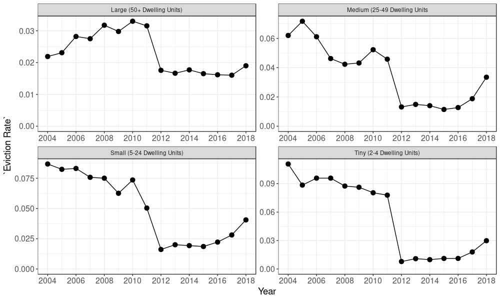

Eviction Rates Across Different Property Sizes in Durham Between 2004 and 2018

```r
include_graphics(path = "Figures/FINALevicratesatsizes.jpeg")
```

First, it is evident that year is intimately related with eviction filing rates. Across all property sizes, we clearly see the elevated rates of eviction filings in the years leading up to the financial crisis, and the precipitous drop in eviction filing rates after 2011. We also see that these eviction rates vary quite drastically across different dwelling unit sizes, and the distributions of the eviction rates across time is also varied. Specifically, in the largest dwelling units, the max average eviction rate is a little under 3.5 percent, whereas in the tiniest dwelling units, the max average eviction rate reaches 10 percent.

Furthermore, we also see that the trends in eviction rates vary. In the largest dwelling unit sizes, eviction rates gradually increased between 2004 and 2008, and eventually peaked in 2010, whereas in the smallest and tiniest property sizes, the eviction rate actually stayed near the same level between 2004 and 2009. Finally, in the past 2 years, eviction rates have increased across all property sizes, but not in the same relative manner. For example, relative to historical rates, the average eviction rate has spiked more dramatically in small and medium units than in tiny and large property sizes. Overall, these different suggest that different trends are present in different property sizes. While it may not be necessary to separate medium and small properties in my analysis since the range of eviction rates are quite comparable, it may be useful to treat large and tiny properties as separate groups.

Next, I look at how eviction rates differ across racial and economic variables. In Figure @ref(fig:dems), I calculate the average eviction rate by tract using the total number of evictions between 2004 and 2018 and dividing by the total number of multi-family dwellings in each tract, then scaling to get a yearly average eviction rate.

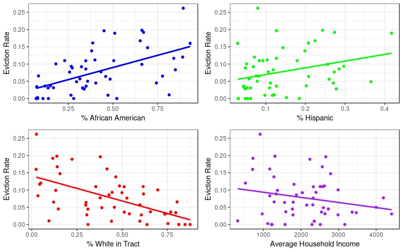

The Impact of Eviction Rates on Different Demographics

```r
include_graphics(path = "Figures/FINALdemsgraphtract.jpeg")
```

I find that the higher the percentage of African American residents and Hispanic residents in a tract, the higher the average eviction rate is. I also find that the eviction rate is slightly higher in more impoverished neighborhoods. Finally, the higher the percentage of white residents in a tract, the lower the average eviction rate is on average across tracts. It becomes clear through these graphs that demographics and eviction rates are highly correlated in Durham.

## Ownership Changes in Durham

I begin by looking at ownership of properties over time. Table @ref(tab:ownership) presents the total number of properties and dwelling units owned by each type of owner in each property size between 1997 and 2018. The results suggest that corporates own the largest number of units in Durham, mainly concentrated in their ownership of the largest properties. Also, individuals are the main owners of the smallest property sizes, as we may have expected.

(#tab:ownership) Summary Statistics on Multi-Family Property Ownership

| Owner Type | Property Size (Units) | Total Properties Owned | Total Dwelling Units Owned |
| --- | --- | --- | --- |
| Corporate | Tiny (2-4) | 310 | 1,044 |
| Corporate | Small (5-24) | 172 | 2,246 |
| Corporate | Medium (25-49) | 72 | 2,716 |
| Corporate | Large (50+) | 388 | 88,886 |
| Individual | Tiny (2-4) | 752 | 2,402 |
| Individual | Small (5-24) | 109 | 1,101 |
| Individual | Medium (25-49) | 22 | 789 |
| Individual | Large (50+) | 30 | 5,247 |
| Other | Tiny (2-4) | 147 | 453 |
| Other | Small (5-24) | 50 | 645 |
| Other | Medium (25-49) | 28 | 1,055 |
| Other | Large (50+) | 20 | 3,613 |
| Unclear | Tiny (2-4) | 19 | 56 |
| Unclear | Small (5-24) | 10 | 99 |
| Unclear | Medium (25-49) | 2 | 68 |
| Unclear | Large (50+) | 35 | 8,126 |

Next, I look at how the ownership of rental properties in Durham have changed since 2000 across different property sizes. In Figure @ref(fig:corpchanges), we can see that since 2000, the proportion of properties under corporate ownership has increased across all property sizes. Specifically, in small and medium sized dwelling units, the proportion of properties under corporate ownership has flipped from being a minority (~40 percent) to a majority (between 62-72 percent) of ownership share. In the largest units, corporate ownership has increased from around 75 percent to 90 percent of all properties, and even in the tiniest units, we have seen corporate ownership increase slightly from around 30 percent to 35 percent ownership share.

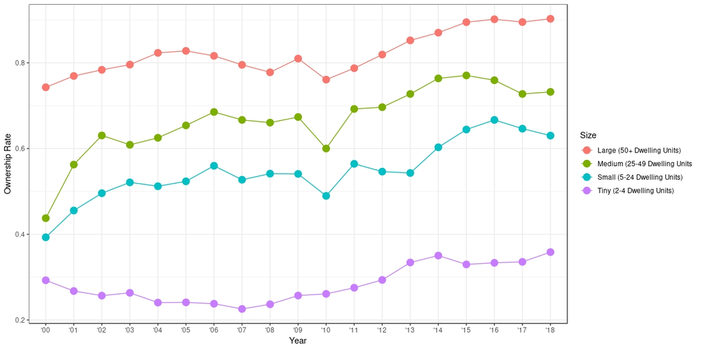

Proportion of Properties Under Corporate Ownership Across Different Property Sizes

```r
include_graphics(path = "Figures/poster1.jpeg")
```

Next, I look to see how ownership amongst corporate owners has changed: specifically, I am interested to see if more owners are based out-of-state. In Figure @ref(fig:statechanges), we can see that the proportion of properties under corporate ownership that are based out-of-state has increased across all property sizes other than the smallest units, where it has stayed the same. In the largest property size, the proportion of properties owned by out-of-state corporates has risen from around 62 percent in 2000 to 80 percent in 2018. In the small and medium property sizes, out-of-state ownership has more than doubled from around 10 – 15 percent in 2000 to around 30 – 40 percent by 2018.

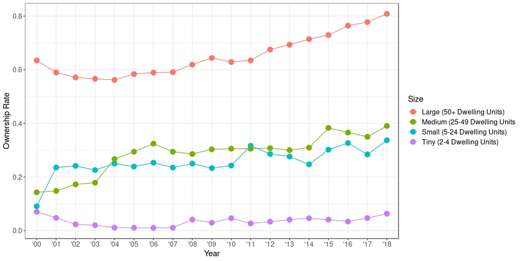

Proportion of Corporate Ownership Based Out-of-State

```r
include_graphics(path = "Figures/posteroutofstatefinal.jpeg")
```

Overall, there is concrete evidence that the composition of multi-family landlords in Durham has changed. In both of these graphs, we can see that the most drastic changes in ownership are occurring in the small and medium sized property units, though almost all property sizes are impacted in some way.

# Empirical Specifications

I subset my data to only contain transactions between the owner types that I am comparing. For example, if I am comparing the eviction rates of corporates and individuals, I subset my data so that it only contains transactions between corporates and corporates, individuals and individuals and corporates and individuals. Furthermore, I look at transaction windows between 1 and 12 months to test the robustness of my results. For example, a transaction window of 6 months implies that I am considering eviction rates 6 months before and 6 months after the transaction date. I choose 12 months as my upper bound because I want to specifically examine the impacts of the ownership change, and since leases of tenants usually last a year, I would expect that if an owner was going to evict the tenant, they would evict them at most within a given year. Otherwise, the owner could simply not renew the tenant’s lease.

I model eviction rates in parcels using a binomial distribution. Specifically, I consider the probability of an eviction occurring at a single dwelling unit in a single month to be a Bernoulli Trial where an eviction can either occur or not occur. Since I do not have information at the dwelling unit level but rather at the parcel level, I aggregate up to the property level using the number of units in the property. The eviction rate at the parcel-level, therefore, can be modeled by a binomial distribution:

$$P_{p}(x | N) = {N\choose k} \cdot p^x(1-p)^{N-x}$$

Specifically, “x” represents the total number of evictions that occur in a given month in a parcel with “N” dwelling units, where the probability of an eviction is given by probability “p”.

Here, I assume that in a given month, there can only be one eviction in a dwelling unit and that an eviction in one dwelling unit is independent of an eviction in any other dwelling unit in that property. This independence assumption is not completely satisfied. For example, consider a small multi-family rental, such as a duplex. The owner of the duplex could be influenced in his/her decision to evict a tenant if he/she has just evicted another tenant, especially if the owner’s livelihood depends on the rental income from the two properties. Furthermore, an eviction in a given dwelling could technically occur more than one time in a given month, though this is incredibly unlikely and never the case in my data. It is sensible to assume this would never occur.

My final model includes the categorical variables of “Ownership Type” and “Period,” which are factor variables that are either a 1 or 0. The ownership type specifies the ownership characteristic I am comparing (i.e. corporate owner = 1 and individual owner = 0). The period specifies whether that owner was owning the property in the pre or post transaction period (i.e. post = 1, pre = 0).

I also include a fixed effect on “Year” in my model. As shown in my data section, the year is intimately connected to the eviction rate, and therefore, I must control for it. Similarly, the percentage of residents that are African American in a tract is also highly correlated with the given eviction rate, and I want to control for the influence of race. I look to see which tract the parcel falls in and I assign the parcel the percentage of African American residents that live in the tract. Applying the same framework, I also include average household income for the tract the parcel falls in, since this also has a slightly negative correlation with the eviction rate in a given tract. I consider these predictors to be numeric variables. I present my final model below:

$$Y_{i} = Binom(P_{i},N_{p(i)}) \\ logit (P_{i}) = B_{0}+ B_{1}I(Owner = Type 1) + B_{2}I(Period = Post) + \\ B_{3}I(Owner = Type 1) *I(Period = Post) + \\
B_{4}(Percent African American In Tract) + B_{5}(Mean Household Income in Tract) + \\
\sum_{y=2004}^{y=2018} B_{y}I(year = y)$$

where i = transaction and Type 1 = one of two levels of ownership characteristic compared.

# Results

## Eviction Rates of Corporate Compared to Individual Landlords

I begin with an investigation of whether the eviction filing rates of corporate versus individual owners vary significantly surrounding a transaction. Because I use a binomial distribution, I convert the exponents of the coefficients of my regression into Odds Ratios representing the likelihood of eviction as compared to a baseline. Here, the baseline of “1” represents an individual’s likelihood of filing an eviction in the pre-transaction period. I present summary statistics of my findings below, and the full regression results can be found in Appendix A, Table A1.

(#tab:res1) Summary Statistics for Owner Type 1 = Corporate v. Individual (6-Month Window)

|  | Odds Ratio | CI Lower | CI Upper | Betas |
| --- | --- | --- | --- | --- |
| Corporate, Pre/ Individual, Pre | 0.25 | 0.23 | 0.28 | $$exp(B_{1})$$ |
| Individual, Post / Individual, Pre | 1.06 | 0.93 | 1.20 | $$exp(B_{2})$$ |
| Corporate, Post / Individual, Pre | 0.28 | 0.19 | 0.42 | $$exp(B_{1} + B_{2} +B_{3})$$ |
| % African American In Tract | 8.48 | 7.14 | 10.08 | $$exp(B_{4})$$ |
| Average Household Income | 1.00 | 1.00 | 1.00 | $$exp(B_{5})$$ |

Table @ref(tab:res1) presents summary statistics for Betas 1 through 5. Specifically, Betas 1, 3, 4 and 5 are statistically significant and Betas 1, 3 and 4 can be deemed practically significant. We can interpret the first row in Table 5 as follows: The likelihood of a corporate evicting a tenant in the pre-transaction period is 0.25x a likely as an individual evicting a tenant in the pre-transaction period, with a confidence interval between 0.23 and 0.28, which is statistically significant because it does not include 1. In other words, an individual is 4x as likely to evict a tenant than a corporate is in the pre-transaction period. Furthermore, a corporate is 0.28x as likely to evict a tenant in the post-transaction period as an individual is in the pre-transaction period. Thus, the likelihood of a corporate filing for eviction against a tenant in both the post and pre-transaction period is lower than an individual’s likelihood of filing for eviction in the pre-transaction period. This finding is statistically significant.

We can also see that the higher the percentage of African American residents in a tract, the higher the likelihood of eviction. The magnitude of the coefficient on this variable suggests that the likelihood of an eviction is highly related to a higher percentage of African American residents. Lastly, while household income is statistically significant and suggests that poorer neighbors have a higher likelihood of experiencing eviction, it is not a practically significant predictor.

Next, I conduct a sensitivity analysis considering different transaction windows (Figure @ref(fig:transres1)). I find that overall, there is not a significant difference in the log-odds of the coefficients over time. Most importantly, we can see that the coefficient on the corporate owner is significantly below “1” across all periods, suggesting that the likelihood of an eviction by a corporate is consistently lower than the likelihood of eviction by an individual.

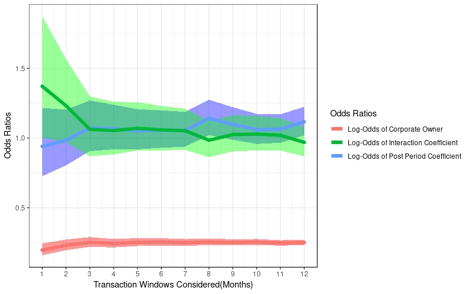

Sensitivity Analysis: Considering Different Transaction Windows

```r
library(knitr)
include_graphics(path = "Figures/FINALcorpindivtransrobus.jpeg")
```

I also check the robustness of this result by excluding LLP, LP and LLCs since it is not always clear whether these observations trace to individuals or corporates. In this model, the results also suggest that individuals are more likely to evict than corporates. A full output of the regression is presented in Appendix A, Table A7.

Finally, in Figure @ref(fig:yearres1), we see that the fixed effect, Year, is meaningful. As expected, in the years of the financial crisis, we see higher likelihoods of eviction than we do in other years. Furthermore, we see that in 2018, specifically, the likelihood of an eviction has risen again.

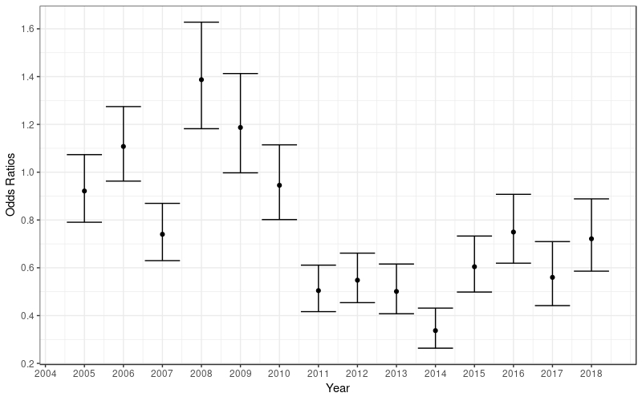

Fixed Effect: Year

```r
include_graphics(path = "Figures/FINALyearfitcorpindiv.jpeg")
```

To determine the robustness of the results, I fit the model for large, medium and small, and tiny dwelling unit property sizes, separately. I consider my medium and small property sizes together since the ranges of eviction rates for these two property sizes are comparable. I present the summary statistics of my findings for the log-odds of the corporate categorical variable below, and a full summary of each of the regression results are presented in Appendix A, Tables A2 – A6.

(#tab:propsizes) Corporate Coefficients Across Property Sizes (6-Month Window)

[output not shown]

## Eviction Rates of Out-Of-State Corporate Compared to In-State Corporate Landlords

Next, I investigate whether the eviction filing rates of out-of-state versus in-state corporate owners vary significantly surrounding a transaction. I present the odds ratios below. My complete regression results are presented in Appendix B, Table B1.

(#tab:res2) Summary Statistics for Owner Type 1 = Out-of-State v. In-State (6-Month Window)

[output not shown]

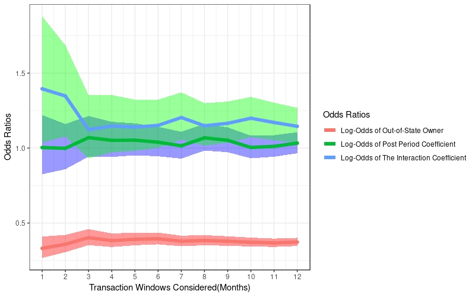

Sensitivity Analysis: Considering Different Transaction Windows

```r
include_graphics(path = "Figures/FINALoutintransrobust.jpeg")
```

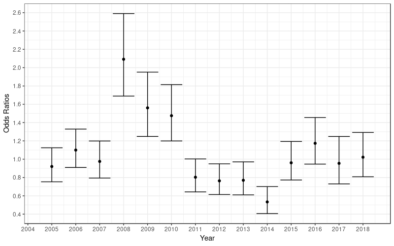

Fixed Effect: Year

```r
include_graphics(path = "Figures/FINALstateyeareffect.jpeg")
```

Furthermore, from @ref(fig:yearres2), we see that the year is again important. With Year = 2004 as the baseline, we can see that eviction filings were twice as likely in 2008 than they were in almost all other years.

To test for robustness, I fit the model for large, medium and small, and tiny dwelling unit property sizes once more. I present the summary statistics of my findings for the coefficient of the out-of-state categorical variable below, and a full summary of each of the regression results are presented in Appendix B, Tables B2 – B6.

(#tab:propsizes2) Out-Of-State Coefficients Across Property Sizes

| Property Size | Odds Ratio for Out-Of-State Owner | Confidence Interval |
| --- | --- | --- |
| Tiny (2-4 Units) | 1.78 | 0.98 – 3.23 |
| Small and Medium (5-49 Units) | 0.82 | 0.59 – 1.14 |
| Large (50+ Units) | 0.86 | 0.74 – 1.00 |

## Eviction Rates of Large Investors Compared to Small Investors

Finally, I investigate whether the eviction filing rates of larger investors are different from the eviction filing rates of small investors amongst both corporate landlords and individuals. This analysis is possible since I have traced back each owner to its Umbrella entity. Without that critical step, I would mislabel many large investor-owners as small investor-owners. I originally define large investors as any investor with more than 15 multi-family properties, following the definition that Raymond et. al, 2016 applies in their paper. I present the odds ratios below. My complete regression results are presented in Appendix C, Table C1.

(#tab:res3) Summary Statistics for Owner Type 1 = Large (15+ Properties) versus Small Investor (6-Month Window)

|  | Odds Ratio | CI Lower | CI Upper | Betas |
| --- | --- | --- | --- | --- |
| Large Investor, Pre/ Small Investor, Pre | 3.16 | 2.65 | 3.77 | $$exp(B_{1})$$ |
| Small Investor, Post / Small Investor, Pre | 1.07 | 1.00 | 1.15 | $$exp(B_{2})$$ |
| Large Investor, Post / Small Investor, Pre | 2.45 | 1.41 | 4.24 | $$exp(B_{1} + B_{2} +B_{3})$$ |
| % African American In Tract | 13.74 | 11.51 | 16.39 | $$exp(B_{4})$$ |
| Average Household Income | 1.00 | 1.00 | 1.00 | $$exp(B_{5})$$ |

As we can see from Table @ref(tab:res3), large investors, defined as corporates or individuals holding more than 15 multi-family properties in Durham, have a higher likelihood of evicting tenants than smaller investors in the pre-transaction period. In the pre-transaction period, large investors are 3.16x as likely to evict and in the post-transaction period, large investors are 2.45x as likely to evict as small investors are in the pre-transaction period. There is no statistically significant evidence to suggest that small investors have different eviction rates in the pre and post transaction periods.

I consider the robustness of this result across different cutoff sizes for a large investor. I start with a lower bound set at ownership of 10 properties. As seen in Figure @ref(fig:robusres3) below, my findings are robust across all different investor size cut-offs. I also consider the robustness of these results across different transaction windows, and again find that the coefficient on the large investor is robust (Figure @ref(fig:transres3)). I do not consider different property sizes in this case since I calculate investor size by the total number of multi-family complexes owned by an entity, so divvying up by property size does not make sense for this analysis.

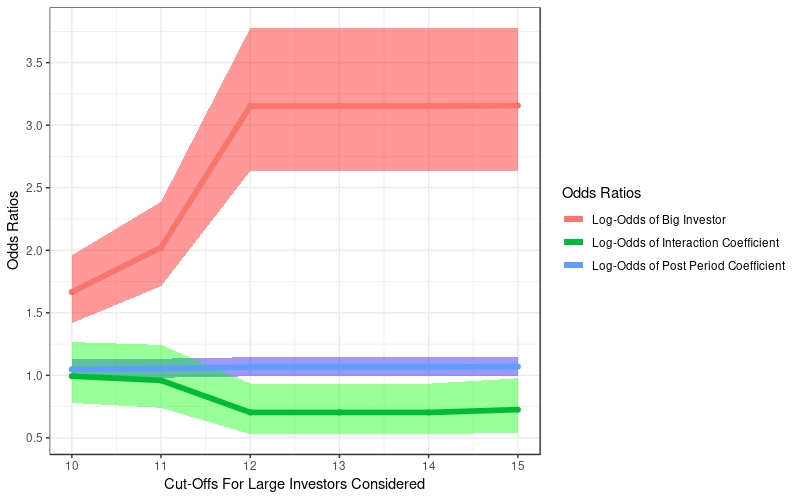

Sensitivity Analysis: Considering Different Cut-offs for Large Investor

```r
include_graphics(path = "Figures/FINALcutoffsrobustness.jpeg")
```

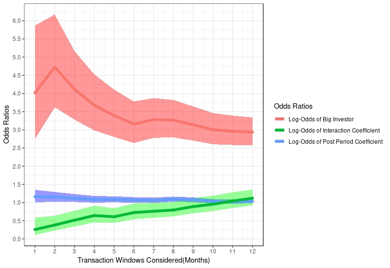

Sensitivity Analysis: Considering Different Transaction Windows

```r
include_graphics(path = "Figures/FINALlargesmalltranswindowrobus.jpeg")
```

# Discussion of Results and Further Research

Overall, I find that the proportion of multi-family dwellings owned by institutional investors have increased in Durham across all property sizes since 2000, which is consistent with the current literature. I also find that amongst corporate owners, specifically, the proportion of owners based out-of-state has increased. Evidently, corporate and out-of-state landlords are becoming the dominant owners of multi-family rental complexes in Durham. Understanding the changes in the ownership make-up of Durham’s multi-family rental market is an important contribution of my thesis. No previous work has attempted to understand how the players in the real-estate market are changing at the corporate and individual level or considered the owner’s location to be significant. My thesis presents evidence of a marked trend across different property sizes. Using the methodology outlined in this paper, I would recommend that future research attempts to conduct similar analyses to understand the structural changes across our nation’s real-estate markets. I also recommend that in research conducted on the multi-family sector, different property sizes be analyzed differently, since trends in both ownership and eviction rates vary significantly across property sizes.

In my research, I find that corporates are less likely to evict than individual landlords are. This finding goes against initial expectations and suggests that individual landlords are more intimately tied to housing instability. However, as discussed in the Literature Review, eviction filings are only one factor that may lead to a tenant’s displacement. There are countless examples of corporations utilizing tactics such as rent hikes and deteriorating living conditions in other rental markets (Abood, 2018; Fields, 2015). On the flip side, informal evictions, such as forcing a tenant to leave through brute force with no legal justification, may be prevalent among individual landlords (Desmond, 2017). Thus, it is impossible to make any definitive conclusions relating landlord type to housing instability through this research alone. Still, this research does suggest that in smaller property sizes, individuals utilize eviction filings at higher rates, while in the largest property size, corporates tend to file evictions at higher rates.

I also find that overall, investors based out-of-state are less likely to evict than in-state owners are. This suggests that the phenomenon of the distanced investor[^5] as discussed in my Literature Review may not necessarily be relevant to Durham. We cannot definitively say that individuals and local corporate owners contribute more or less to housing instability, but we can consider potential reasons that explain differences in eviction filing rates. One reason may be that in the Durham rental market, the livelihoods of individual owners and local corporates are more directly tied to the rental income from their tenants. Thus, these landlords may not have the flexibility and band-with that larger landlords do.

Yet, I also find that investors who own more than 15 multi-family properties in Durham, which I consider to be “large” investors, are more likely to evict tenants than smaller investors are when considering both corporate landlords and individuals. The explanation that larger investors are more flexible, and therefore evict at lower rates, is not quite adequate. This finding suggests that perhaps, we must pay more attention to consolidation by a few landlords no matter what type of entity they are, as landlords with a larger consolidation of units seem to be more likely to evict. This finding is consistent with the finding by Raymond et. al in their 2016 case study on Atlanta that larger investors in the single-family rental market, defined as investors that hold more than 15 single-family rental units, evict at higher rates (Raymond et. al, 2016).

One limitation of my thesis is that it does not consider other potentially important predictors that would give idiosyncratic insight at the property-level. For example, it would be helpful to have information on rents across these units. Unfortunately, this data was not possible to retrieve for the purposes of this research. Similarly, property taxes or improvement values would be another important variable in understanding potential landlord behavior and motivation. In future research, looking at building permits or other property value assessments may yield important insight into investor strategy, which could be analyzed quantitatively using Mallach’s framework (Mallach, 2010).

There is much more work to be done to understand the true causes of housing instability in Durham County. As property values and rents continue to rise, the types of residents who can afford to live in the city of Durham will change. Poorer residents who can no longer afford the rising rents will have to move. This type of phenomenon exists outside the confines of formal eviction processes but is just as significant in the creation of housing instability.

This research should be extended to other communities to understand changes in other real-estate markets. Most importantly, similar analyses between the relationship of landlords and housing instability should be conducted in other areas with high rates of displacement. Moving forward, researchers must think creatively about potential proxies to measure displacement. More qualitative investigation may be helpful into factors such as the living conditions of properties under different types of ownership. Finally, more nuanced research must be conducted to determine whether certain biases exist in the rental space that lead to the higher eviction rates amongst low-income and minority groups.

# Conclusion

For better or for worse, our landlords are changing. More institutional owners are buying rental properties and taking share away from many of the small investors with small inventories that used to represent the hallmark landlord. At the same time, more cities across the United States are becoming majority renters, which makes it even more important to understand what these new landlords imply for the housing stability of tenants. Housing instability encompasses multiple challenges, many of which are difficult to measure quantitatively. My thesis hopes to shed light on one factor contributing to the displacement of tenants: eviction filings. I find that in most property sizes, individual landlords are more likely to evict than corporate landlords are and that in-state corporates, specifically, evict at higher rates than out-of-state corporate landlords do. I also find that large investors, defined as those with more than 15 multi-family properties in Durham, are more likely to evict than small investors are. This research begins to shed a light on landlord characteristics related to eviction rates. However, there must be more investigation into other quantitative and qualitative factors contributing to housing instability in order to obtain a more complete picture for why tenants continue to be displaced. Similar analyses must be conducted in other cities to understand how the changing landscapes of ownership in the real-estate market will continue to impact the renters of this nation in the future.

# Appendix

## Appendix A: Corporate and Individual Transactions - 6-Month Windows

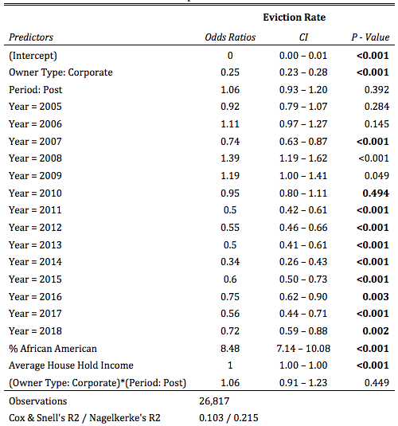

Eviction Likelihoods in All Properties

```r
library(knitr)
include_graphics(path = "Figures/A1.png")
```

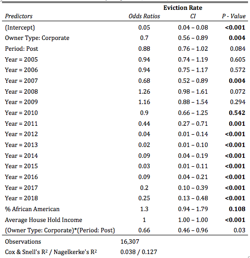

Eviction Likelihoods in Tiny Properties (2-4 Units)

```r
include_graphics(path = "Figures/A2.png")
```

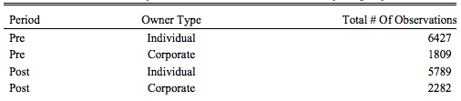

Total # of Monthly Eviction Rate Observations for Tiny Property Transactions

```r
include_graphics(path = "Figures/A3.png")
```

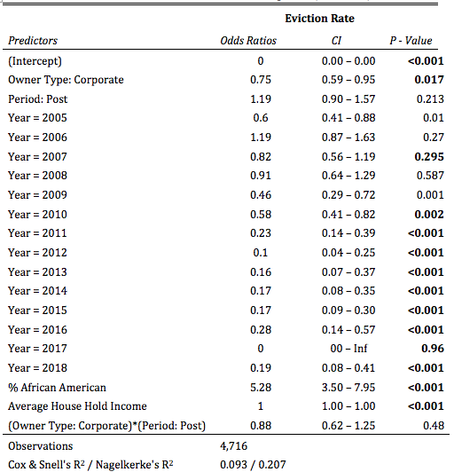

Eviction Likelihoods in Medium & Small Properties (5-49 Units)

```r
include_graphics(path = "Figures/A4.png")
```

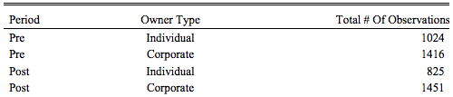

Total # of Monthly Eviction Rate Observations for Medium & Small Property Transactions

```r
include_graphics(path = "Figures/A5.png")
```

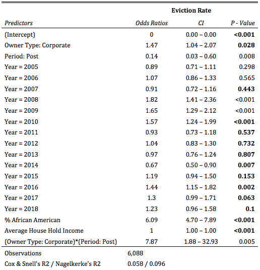

Eviction Likelihoods in Largest Properties (50+ Units)

```r
include_graphics(path = "Figures/A6.png")
```

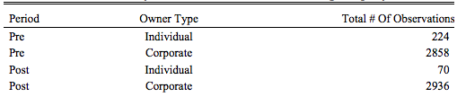

Total # of Monthly Eviction Rate Observations for Large Property Transactions

```r
include_graphics(path = "Figures/A7.png")
```

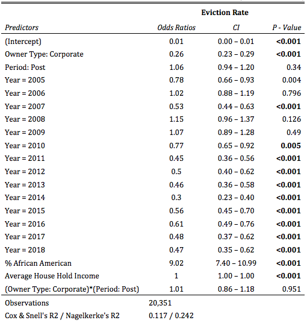

Eviction Likelihoods Without LLC, LP or LLPs Considered (Robustness Check)

```r
include_graphics(path = "Figures/A8.png")
```

## Appendix B: Out-of-State and In-State Corporate Transactions - 6-Month Window

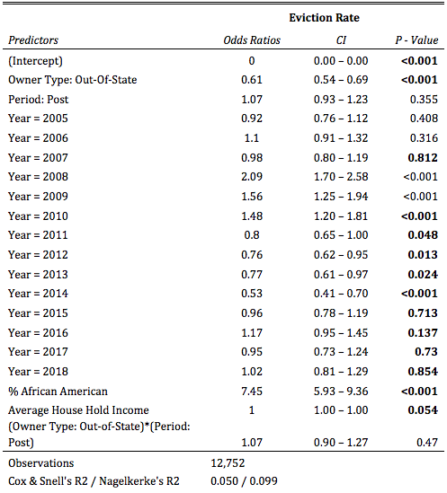

Eviction Likelihoods in All Properties

```r
include_graphics(path = "Figures/B1.png")
```

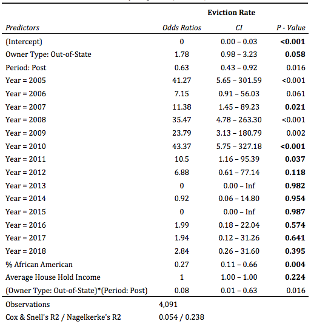

Eviction Likelihoods in Tiny Properties (2-4 Units)

```r
include_graphics(path = "Figures/B2.png")
```

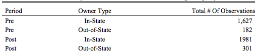

Total # of Monthly Eviction Rate Observations for Tiny Property Transactions

```r
include_graphics(path = "Figures/B3.png")
```

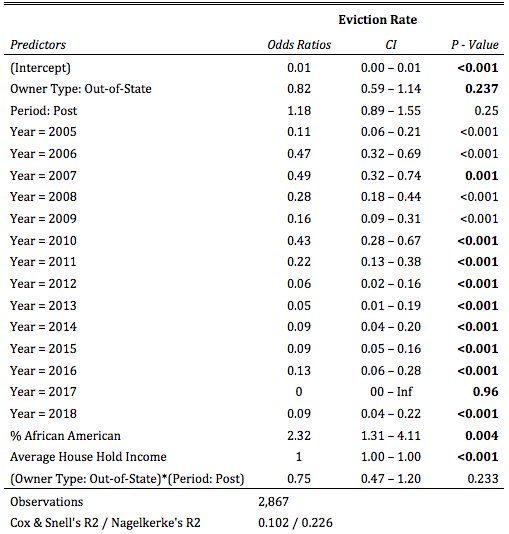

Eviction Likelihoods in Medium & Small Properties (5-49 Units)

```r
include_graphics(path = "Figures/B4.png")
```

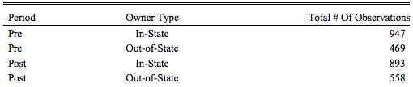

Total # of Monthly Eviction Rate Observations for Medium & Small Property Transactions

```r
include_graphics(path = "Figures/B5.png")
```

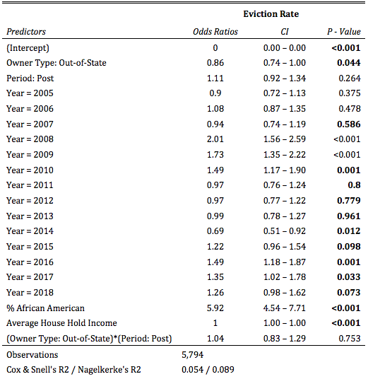

Eviction Likelihoods in Largest Properties (50+ Units)

```r
include_graphics(path = "Figures/B6.png")
```

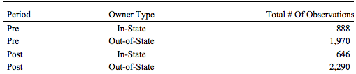

Total # of Monthly Eviction Rate Observations for Large Property Transactions

```r
include_graphics(path = "Figures/B7.png")
```

## Appendix C: Large and Small Investor Transactions (6-Month Window)

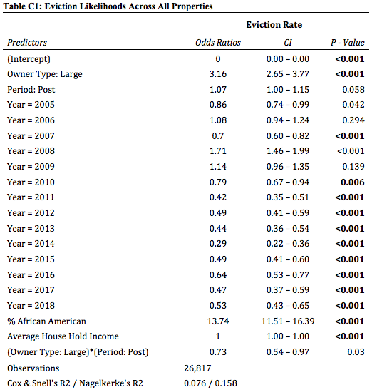

Eviction Likelihoods Across All Properties

```r
include_graphics(path = "Figures/C1.png")
```

# References

Abood, Maya. Wall Street Landlords Turn American Dream into a Nightmare. ACCE Institute, 2018.

AMERICA’S RENTAL HOUSING: EVOLVING MARKETS AND NEEDS. Joint Center for Housing Studies of Harvard University, 2013, pp. 22–27, AMERICA’S RENTAL HOUSING: EVOLVING MARKETS AND NEEDS.

1. Association for Neighborhood and Housing Development (ANHD). (2009). Predatory equity: Evolution of a crisis. The threat to New York’s affordable rental housing, 2005–2009. New York: Association for Neighborhood and Housing Development.
2. Bernanke, B. (2012). Housing Markets in Transition [Press release]. Retrieved from https://www.federalreserve.gov/newsevents/speech/bernanke20110210a.html.
3. Berry, M. 2000. Investment in rental housing in Australia: Small landlords and institutional investors. Housing Studies 15 (5): 661–81. doi:10.1080/02673030050134547.
4. Burns, Rebecca. “You Think Your Landlord Is Bad? Try Renting From Wall Street.” The Intercept, 20 Jan. 2018, theintercept.com/2018/01/20/you-think-your-landlord-is-bad-try-renting-from-wall-street/.
5. Burt, Martha. 2001. “Homeless Families, Singles, and Others: Findings from the 1996 National Survey of Homeless Assistance Providers and Clients.” Housing Policy Debate 12:737–80.
6. Desmond, Matthew. Evicted: Poverty and Profit in the American City. Penguin Books, 2017.
7. Desmond, Matthew, and Carl Gershenson. 2016. Housing and Employment Insecurity among the Working Poor. Social Problems, 63(1), 46-67.
8. Desmond, Matthew, and Carl Gershenson. 2016. “Who gets evicted? Assessing individual, neighborhood, and network factors.” Social Science Research, 1-16.
9. Desmond, Matthew, Carl Gershenson, and Barbara Kiviat. 2015. “Forced Relocation and Residential Instability among Urban Renters.” Social Service Review 89:227–62.
10. Desmond, Matthew and Rachel Tolbert Kimbro. 2015. “Eviction’s Fallout: Housing, Hardship, and Health.” Social Forces 94:295–324.
11. Eanes, Zachery. “Apartment Rents in the Triangle Are Once Again Growing Faster than US Average.” Https://Www.newsobserver.com, Raleigh News & Observer, 30 Jan. 2019, www.newsobserver.com/news/business/article225279430.html.
12. Eisfeldt, Andrea, and Andrew Demers. “Total Returns to Single Family Rentals.” (2015).
13. Evans, J., & Habbard, P. (2008). From shareholder value to private equity: The changing face of financialisation of the economy. Transfer: European Review of Labour and Research, 2008(14), 1.
14. Fields DJ (2018) Constructing a New Asset Class: Property-led Financial Accumulation after the Crisis. Economic Geography, 94(2), 118-140.
15. Fields DJ (2015) Contesting the Financialization of Urban Space: Community Organizations and the Struggle to Preserve Affordable Rental Housing in New York City. Journal of Urban Affairs, 37(2), 144-165.
16. Fields DJ, Kohli R & Schafran A (2016) The Emerging Economic Geography of Single-Family Rental Securitization (Working Paper).
17. Fields DJ & Uffer S (2016) The financialisation of rental housing: A comparative analysis of New York City and Berlin. Urban Studies, 53(7), 1486-1502.
18. Florida, Richard. “Why Homeownership Is Falling Across America.” CityLab, The Atlantic Monthly Group, 3 May 2018, www.citylab.com/equity/2018/05/the-great-housing-reset/559466/.
19. Flowers, Andrew. “How We Undercounted Evictions By Asking The Wrong Questions.” FiveThirtyEight, FiveThirtyEight, 16 Sept. 2016, fivethirtyeight.com/features/how-we-undercounted-evictions-by-asking-the-wrong-questions/.
20. Ford, Frank, et al. “The role of investors in the one-to-three family REO market: The case of Cleveland.” Washington, DC: What Works Collaborative (2013).
21. “Freddie Mac Prices $248 Million Offering of Guaranteed Tax-Exempt ML Certificates” (May 2018). Retrieved from https://www.cnbc.com/2018/05/15/globe-newswire-freddie-mac-prices-248-million-offering-of-guaranteed-tax-exempt-ml-certificates.html
22. “Freddie Mac Prices $1 Billion Multifamily K-Deal, K-079” (August 2018). Retrieved from https://www.cnbc.com/2018/08/10/globe-newswire-freddie-mac-prices-1-billion-multifamily-k-deal-k-079.html
23. “Freddie Mac Prices $912 Million Multifamily K-Deal, K-C02” (September 2018). Retrieved from https://globenewswire.com/news-release/2018/09/25/1575740/0/en/Freddie-Mac-Prices-912-Million-Multifamily-K-Deal-K-C02.html
24. Frederick, T. J., Chwalek, M. , Hughes, J. , Karabanow, J. and Kidd, S. (2014), HOW STABLE IS STABLE? DEFINING AND MEASURING HOUSING STABILITY. J. Community Psychol., 42: 964-979. doi:10.1002/jcop.21665
25. French, S., Leyshon, A., & Wainwright, T. (2011). Financializing space, spacing financialization. Progress in Human Geography, 35(6), 798–819. https://doi.org/10.1177/0309132510396749
26. Gottesdiener, Laura. “Wall Street’s hot new financial product: your rent check.” Mother Jones, Mother Jones and the Foundation for National Progress, March/April 2014, https://www.motherjones.com/politics/2014/02/blackstone-rental-homes-bundled-derivatives/
27. Herbert, Christopher Edward, Irene Lew, and Rocio Sanchez-Moyano. The role of investors in acquiring foreclosed properties in low-and moderate-income neighborhoods: A review of findings from four case studies. What Works Collaborative, 2013a.
28. Herbert, Christopher E., Lauren Lambie‐Hanson, Irene Lew, and Rocio Sanchez‐Moyano. 2013b. “The Role of Investors in Acquiring Foreclosed Properties in Boston.” Washington, DC: What Works Collaborative.
29. Immergluck, Dan. 2013. “The Role of Investors in the Single‐Family Market in Distressed Neighborhoods: The Case of Atlanta.” Washington, DC: What Works Collaborative.
30. Lee, Hyojung. “Who Owns Rental Properties, and Is It Changing?” Blog | Joint Center for Housing Studies of Harvard University, Harvard Joint Center for Housing Studies, 29 Mar. 2018, www.jchs.harvard.edu/blog/who-owns-rental-properties-and-is-it-changing/.
31. Logan, Tim. “American Homes 4 Rent to Issue Bonds on Single-Family Rentals.” Los Angeles Times, Los Angeles Times, 6 May 2014, www.latimes.com/business/realestate/la-fi-mo-american-homes-4-rent-bond-issue-20140506-story.html.
32. Krueger, Sarah. “With 20 New Residents Each Day, Demand for Durham Homes Outpaces Supply.” WRAL.com, 29 Mar. 2018, www.wral.com/with-20-new-residents-each-day-demand-for-durham-homes-outpaces-supply-/17452261/.
33. Kyle Walker (2018). tidycensus: Load US Census Boundary and Attribute Data as ‘tidyverse’ and ‘sf’-Ready Data Frames. R package version 0.8.1. https://CRAN.R-project.org/package=tidycensus.
34. Maciag, Mike. “Gentrification in America Report.” Governing Magazine: State and Local Government News for America’s Leaders, Governing, Feb. 2015, www.governing.com/gov-data/census/gentrification-in-cities-governing-report.html.
35. Mallach, Alan (2010). Meeting the challenge of distressed property investors in America’s neighborhoods. New York, NY: Local Initiatives Support Corporation.
36. Mallach, Alan. 2013. “Investors and Housing Markets in Las Vegas: A Case Study.” Washington, DC: What Works Collaborative.
37. Mills, James, Raven Molloy, and Rebecca Zarutskie. “Large‐Scale Buy‐to‐Rent Investors in the Single‐Family Housing Market: The Emergence of a New Asset Class.” Real Estate Economics (2017).
38. Morenoff, J. D., Sampson, R. J., & Raudenbush, S. W. (2001). Neighborhood Inequality, Collective Efficacy, And The Spatial Dynamics Of Urban Violence. Criminology, 39(3), 517-558.
39. Kolomatsky, Michael. “Mom and Pop Own Fewer Rental Units.” The New York Times, The New York Times, 31 Aug. 2017, www.nytimes.com/2017/08/31/realestate/institutional-investors-landlord.html.
40. Raymond, Elora L and Duckworth, Richard and Miller, Benjmain and Lucas, Michael and Pokharel, Shiraj, Corporate Landlords, Institutional Investors, and Displacement: Eviction Rates in Single family Rentals (2016-12-01). FRB Atlanta Community and Economic Development Discussion Paper No. 2016-4.
41. Sampson, R. J., Raudenbush, S. W., & Earls, F. (1997). Neighborhoods and Violent Crime: A Multilevel Study of Collective Efficacy. Science, 277.
42. St. Louis Fed. “Homeownership Rate in The United States from 1990 to 2018.” Statista - The Statistics Portal, Statista, www.statista.com/statistics/184902/homeownership-rate-in-the-us-since-2003/.
43. Szekely, Balazs. “Renters Became the Majority Population in 22 Big US Cities.” Renters Became the Majority Population , 2019 Rentcafe, 29 Jan. 2018, www.rentcafe.com/blog/rental-market/market-snapshots/change-renter-vs-owner-population-2006-2016/.
44. “The Durham Human Relations Commission 3018 Report on Evictions Crisis in Durham County.” Durhamnc.gov, 2018, https://durhamnc.gov/DocumentCenter/View/20496/Durham-Eviction-Report-and-Recommendations---March-6-2018-?bidId=
45. United Nations Human Rights Office of the High Commissioner. “Forced Evictions.” OCHR, 2014, www.ohchr.org/Documents/Publications/FS25.Rev.1.pdf.
46. US Census Bureau. “Rental Housing Finance Survey (RHFS).” Census Bureau QuickFacts, United States Census Bureau, 30 Apr. 2018, www.census.gov/programs-surveys/rhfs.html.
47. U.S. Census Bureau, Homeownership Rate for the United States [RHORUSQ156N], retrieved from FRED, Federal Reserve Bank of St. Louis; https://fred.stlouisfed.org/series/RHORUSQ156N, April 11, 2019.
48. Willets, Sarah. “A New Program Is Shedding Light on Why Durham County Has Such a Huge Eviction Problem.” INDY Week, 2018 Indy Week, 3 Jan. 2018, indyweek.com/news/durham/new-program-shedding-light-durham-county-huge-eviction-problem/.
49. Willets, Sarah. “Durham County Has an Eviction Crisis. Can a New Diversion Program Help?” INDY Week, 19 July 2017, indyweek.com/news/durham/durham-county-eviction-crisis.-can-new-diversion-program-help/.
50. Vaughan, Dawn Baumgartner. “Richer People Are Moving to Durham. Here’s How That Will Change Housing.” Https://Www.newsobserver.com, Raleigh News & Observer, 6 Dec. 2018, www.newsobserver.com/news/local/article222729045.html#storylink=cpy.
[^1]: The Rental Housing Finance Survey divides all landlords into two groups: individual landlords and non-individual landlords. Non-individual landlords are considered to be the following: trustee for estate, LLP, LP, or LLC, tenant in common, general partnership, REIT, real estate corporation, housing cooperative, non-profit organization and other. I give my own definition of what “corporate” ownership entails using the Rental Housing Finance Survey’s classifications as my guide. I will discuss this encoding in detail in the Data section.
[^2]: This includes all landlords other than individuals as defined by the Rental Housing Finance Survey.
[^3]: The only paper that attempts to establish a quantifiable relationship between eviction rates and corporate ownership is a paper by Raymond et. al called “Corporate Landlords, Institutional Investors, and Displacement: Eviction Rates in Single family Rentals.” The authors limit their investigation to the single-family rental market. My thesis, unlike the paper mentioned, focuses exclusively on the multi-family rental market.
[^4]: Large investors were defined as investors that held more than 15 single-family rental properties.
[^5]: The distanced investor is a case where it is not completely clear who the landlord is, and tenants perceive some difficulty in reaching their landlord to discuss their personal situation.